# Прогнозирование заказов такси

**Описание проекта**

Компания «Чётенькое такси» собрала исторические данные о заказах такси в аэропортах. Чтобы привлекать больше водителей в период пиковой нагрузки, нужно спрогнозировать количество заказов такси на следующий час. Постройте модель для такого предсказания.

Значение метрики *RMSE* на тестовой выборке должно быть не больше 48.

**Цель проекта**

Построить модель машинного обучения для прогноза количества заказов такси на следующий час для привлечения больше водителей в период пиковой нагрузки.

**План работы**

1. Загрузить данные и выполнить их ресемплирование по одному часу.
2. Проанализировать данные.
3. Обучить разные модели с различными гиперпараметрами. Сделать тестовую выборку размером 10% от исходных данных.
4. Проверить данные на тестовой выборке и сделать выводы.

**Описание данных**

Данные лежат в файле `taxi.csv`.

Целевой признак:

- `'num_orders'` — количество заказов такси.

# Содержание

## Подготовка

### Импорт библиотек

```python
import time

import pandas as pd
import numpy as np
import matplotlib.pyplot as plt
import matplotlib.ticker as ticker
import seaborn as sns
import lightgbm as lgb

from IPython.display import HTML
from statsmodels.tsa.seasonal import seasonal_decompose
from catboost import CatBoostRegressor

from sklearn.compose import ColumnTransformer
from sklearn.pipeline import Pipeline
from sklearn.preprocessing import StandardScaler
from sklearn.model_selection import train_test_split
from sklearn.metrics import mean_squared_error
from sklearn.linear_model import LinearRegression
from sklearn.ensemble import RandomForestRegressor
from sklearn.tree import DecisionTreeRegressor
```

```python
!pip install phik -q
import phik
```

```python
plt.rcParams["figure.figsize"] = (15, 6)
```

```python
RANDOM_STATE = 12345
```

### Создание функций

Создадим функции, которые нам потребуются в работе.

```python
# Функция для предварительного изучения
# общей информации о данных.
def data_research(dataset):


    # Отображение 5 первых и последних строк.
    display(dataset.head())
    display(dataset.tail())
    print()


    # Отображение информации о данных.
    display(HTML('<h3>Общая информация о данных</h3><br>'))
    print(dataset.info())


    # Отображение списка наименования столбцов.
    display(HTML('<h3>Наименования столбцов</h3><br>'))
    print(dataset.columns)


    # Проверка расположения порядка даты и времени.
    display(HTML('<br><h3>Порядок даты и времени</h3><br>'))

    if data.index.is_monotonic == True:
        print('Данные расположены в хронологическом порядке')

    else:
        print('Данные не имеют хронологического порядка')


    # Проверка на пропуски и их изучение.
    display(HTML('<br><h3>Количество и доля пропущенных значений</h3><br>'))

    if dataset.isna().sum().any():

        display(HTML(
            f'<b>Количество пропусков во всем датафрейме: </b>'\
            f'{dataset.isna().sum().sum()} '\
            f'({round((dataset.isna().sum().sum() / (dataset.shape[0] * dataset.shape[1]) * 100), 1)}%)<br>')
               )

        display(HTML(
            f'<b>Записи, имеющие хотя бы один пропуск: </b>'\
            f'{dataset[dataset.columns].isna().any(axis=1).sum()} '\
            f'({round((dataset[dataset.columns].isna().any(axis=1).sum() / dataset.shape[0] * 100), 1)}%)<br>')
               )

        display(HTML('<b>Количество пропусков в каждом столбце: </b>'))
        display(pd.DataFrame({
            'count': dataset.isna().sum(),
            '%': dataset.isna().mean() * 100
            }).style.set_precision(1).background_gradient('coolwarm'))

    else:
        print('Пропуски отсутствуют')


    # Проверка на явные дубликаты.
    display(HTML('<br><h3>Количество дубликатов в датафрейме</h3><br>'))

    if dataset.duplicated().sum() != 0:

        print(f'Всего: {dataset.duplicated().sum()} '
              f'({(dataset.duplicated().sum() / dataset.shape[0]):.2%} '\
              f'от общего размера)')

    else:
        print('Явные дубликаты отсутствуют')


    # Проверка уникальных значений признаков.
    display(HTML('<br><h3>Уникальные значения в датафрейме</h3><br>'))

    for column in dataset.columns:
        display(HTML(f'<b>Уникальные значения в столбце "{column}": </b>'\
                     f'{len(dataset[column].unique())}'))

        print(dataset.sort_values(by=column)[column].unique())



    if len(dataset.columns) != 0:

        # Изучение информации о количественных данных.
        display(HTML('<br><h3>Описание данных</h3>'))
        display(dataset.describe())


        # Построение графиков для количественных данных.
        display(HTML(
            '<br><h3>Гистограммы для всех числовых столбцов</h3><br>'
        ))
        num_plots = len(dataset.columns)
        num_rows = (num_plots + 1) // 2

        # Создание фигуры и осей.
        fig, axes = plt.subplots(num_rows, 2, figsize=(14, 5 * num_rows))

        # Если количество строк равно 1,
        # преобразуем axes в двумерный массив.
        if num_rows == 1:
            axes = np.expand_dims(axes, axis=0)

        # Построение гистограмм.
        for i, column in enumerate(dataset.columns):
            row = i // 2
            col = i % 2
            sns.histplot(data=dataset, x=column, bins=20, ax=axes[row, col])
            axes[row, col].grid(True)
            axes[row, col].set_title(
                f'Распределение значений признака {column}'
            )
            axes[row, col].set_xlabel(column)
            axes[row, col].set_ylabel('Количество записей')
            axes[row, col].tick_params(axis='x', rotation=90)

        # Скрытие последнего пустого графика,
        # если количество столбцов нечетное.
        if num_plots % 2 != 0:
            fig.delaxes(axes[-1, -1])

        # Настройка макета.
        plt.tight_layout()
        plt.show()

    else:
        pass
```

### Загрузка данных

Загружаем данные из csv-файла в датафрейм.

```python
data = pd.read_csv('/datasets/taxi.csv', index_col=[0], parse_dates=[0])
```

### Изучение общей информации о датафрейме

Изучим информацию при помощи функции `data_research`.

| datetime | num_orders |
| --- | --- |
| 2018-03-01 00:00:00 | 9 |
| 2018-03-01 00:10:00 | 14 |
| 2018-03-01 00:20:00 | 28 |
| 2018-03-01 00:30:00 | 20 |
| 2018-03-01 00:40:00 | 32 |

| datetime | num_orders |
| --- | --- |
| 2018-08-31 23:10:00 | 32 |
| 2018-08-31 23:20:00 | 24 |
| 2018-08-31 23:30:00 | 27 |
| 2018-08-31 23:40:00 | 39 |
| 2018-08-31 23:50:00 | 53 |

Общая информация о данных

```
<class 'pandas.core.frame.DataFrame'>
DatetimeIndex: 26496 entries, 2018-03-01 00:00:00 to 2018-08-31 23:50:00
Data columns (total 1 columns):
 #   Column      Non-Null Count  Dtype
---  ------      --------------  -----
 0   num_orders  26496 non-null  int64
dtypes: int64(1)
memory usage: 414.0 KB
None
```

Наименования столбцов

```
Index(['num_orders'], dtype='object')
```

Порядок даты и времени

```
Данные расположены в хронологическом порядке
```

Количество и доля пропущенных значений

```
Пропуски отсутствуют
```

Количество дубликатов в датафрейме

```
Всего: 26415 (99.69% от общего размера)
```

Уникальные значения в датафрейме

**Уникальные значения в столбце "num_orders":** 81

```
[  0   1   2   3   4   5   6   7   8   9  10  11  12  13  14  15  16  17
  18  19  20  21  22  23  24  25  26  27  28  29  30  31  32  33  34  35
  36  37  38  39  40  41  42  43  44  45  46  47  48  49  50  51  52  53
  54  55  56  57  58  60  61  62  64  65  66  67  68  71  76  78  80  81
  82  87  90  91  94  95  98  99 119]
```

Описание данных

|  | num_orders |
| --- | --- |
| count | 26496.000000 |
| mean | 14.070463 |
| std | 9.211330 |
| min | 0.000000 |
| 25% | 8.000000 |
| 50% | 13.000000 |
| 75% | 19.000000 |
| max | 119.000000 |

Гистограммы для всех числовых столбцов

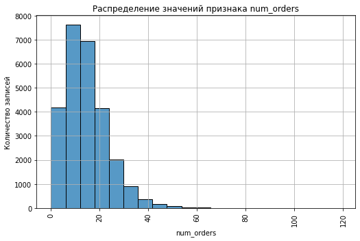

```python
data_research(data)
```

Для дальнейшей работы нам необходимо ресемплировать данные по одному часу.

```python
data = data.resample('1H').sum()
```

Изучим данные еще раз после проведения ресемплирования.

| datetime | num_orders |
| --- | --- |
| 2018-03-01 00:00:00 | 124 |
| 2018-03-01 01:00:00 | 85 |
| 2018-03-01 02:00:00 | 71 |
| 2018-03-01 03:00:00 | 66 |
| 2018-03-01 04:00:00 | 43 |

| datetime | num_orders |
| --- | --- |
| 2018-08-31 19:00:00 | 136 |
| 2018-08-31 20:00:00 | 154 |
| 2018-08-31 21:00:00 | 159 |
| 2018-08-31 22:00:00 | 223 |
| 2018-08-31 23:00:00 | 205 |

Общая информация о данных

```
<class 'pandas.core.frame.DataFrame'>
DatetimeIndex: 4416 entries, 2018-03-01 00:00:00 to 2018-08-31 23:00:00
Freq: H
Data columns (total 1 columns):
 #   Column      Non-Null Count  Dtype
---  ------      --------------  -----
 0   num_orders  4416 non-null   int64
dtypes: int64(1)
memory usage: 69.0 KB
None
```

Наименования столбцов

```
Index(['num_orders'], dtype='object')
```

Порядок даты и времени

```
Данные расположены в хронологическом порядке
```

Количество и доля пропущенных значений

```
Пропуски отсутствуют
```

Количество дубликатов в датафрейме

```
Всего: 4165 (94.32% от общего размера)
```

Уникальные значения в датафрейме

**Уникальные значения в столбце "num_orders":** 251

```
[  0   1   2   3   4   5   6   7   8   9  10  11  12  13  14  15  16  17
  18  19  20  21  22  23  24  25  26  27  28  29  30  31  32  33  34  35
  36  37  38  39  40  41  42  43  44  45  46  47  48  49  50  51  52  53
  54  55  56  57  58  59  60  61  62  63  64  65  66  67  68  69  70  71
  72  73  74  75  76  77  78  79  80  81  82  83  84  85  86  87  88  89
  90  91  92  93  94  95  96  97  98  99 100 101 102 103 104 105 106 107
 108 109 110 111 112 113 114 115 116 117 118 119 120 121 122 123 124 125
 126 127 128 129 130 131 132 133 134 135 136 137 138 139 140 141 142 143
 144 145 146 147 148 149 150 151 152 153 154 155 156 157 158 159 160 161
 162 163 164 165 166 167 168 169 170 171 172 173 174 175 176 177 178 179
 180 182 183 184 185 186 187 188 189 190 191 192 193 194 195 196 197 198
 200 201 202 203 204 205 207 208 210 211 212 213 214 215 216 217 219 220
 222 223 224 226 227 229 230 231 232 234 238 239 240 242 245 246 247 248
 249 251 253 254 263 265 267 268 272 273 276 281 295 342 408 437 462]
```

Описание данных

|  | num_orders |
| --- | --- |
| count | 4416.000000 |
| mean | 84.422781 |
| std | 45.023853 |
| min | 0.000000 |
| 25% | 54.000000 |
| 50% | 78.000000 |
| 75% | 107.000000 |
| max | 462.000000 |

Гистограммы для всех числовых столбцов

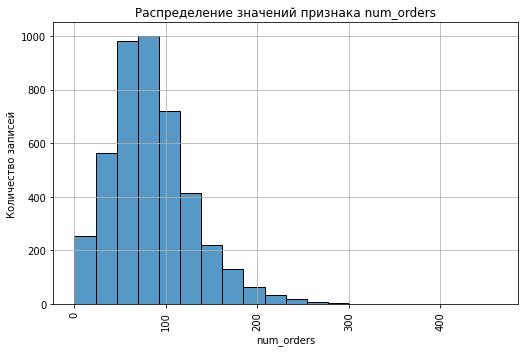

```python
data_research(data)
```

### Вывод

Данные загружены, они соответствуют описанию задачи.

Всего у нас представлено 26496 записей за период с 1 марта по 31 августа 2018 года по количеству заказов такси с интервалом в 10 минут. После ресемплирования у нас осталось 4416 записей с интервалом в 1 час.

Оформление и типы данных соответствуют содержимому в столбцах. Данные расположены в хронологическом порядке. Пропуски отсутствуют.

Доля явных дубликатов в данных составляет более 90%, что закономерно, ведь в данных мы имеем лишь 1 столбец и многие значения могут повторяться.

Значения по количеству заказов распределены нормально, но пик графика смещен влево, в конце графика заметен большой хвост из больших значений, которые встречаются редко.

Количество заказов такси с интервалом в 10 минут варьируется от 0 до 119, в среднем на каждые 10 минут приходится 14 заказов. Заказы с интервалом в 1 час имеют размах гораздо больше - от 0 до 462, в среднем на 1 час приходится 84 заказа.

Вернуться к содержанию

## Анализ

Построим график временного ряда по количеству заказов такси.

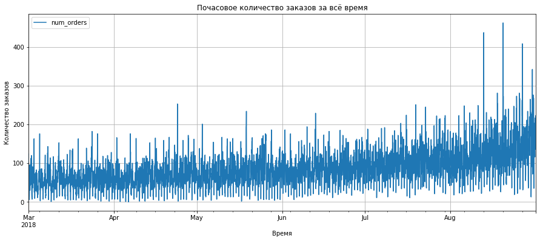

```python
data.plot(
    title='Почасовое количество заказов за всё время',
    xlabel='Время',
    ylabel='Количество заказов',
    grid=True
);
```

По такому графику сложно что-то сказать. Попробуем укрупнить временной интервал.

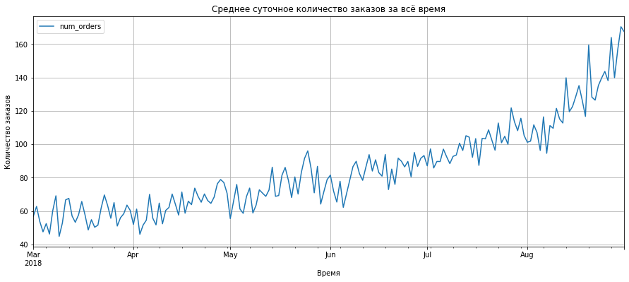

```python
data.resample('1D').mean().plot(
    title='Среднее суточное количество заказов за всё время',
    xlabel='Время',
    ylabel='Количество заказов',
    grid=True);
```

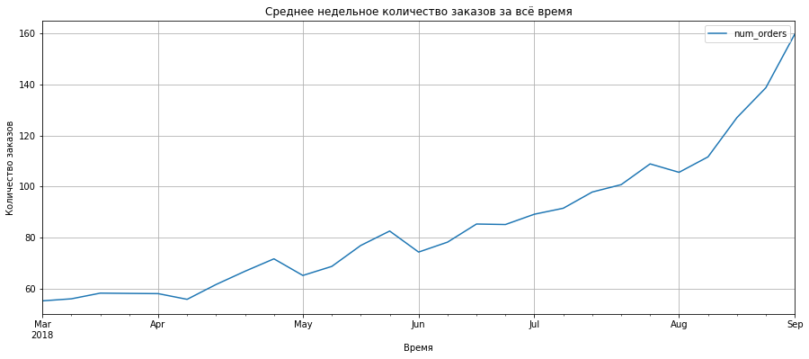

```python
data.resample('1W').mean().plot(
    title='Среднее недельное количество заказов за всё время',
    xlabel='Время',
    ylabel='Количество заказов',
    grid=True);
```

Заметен тренд на рост среднего количества заказов со временем, с каждым месяцем оно становится больше. Рост наблюдается, начиная с апреля, затем в августе он приобретает ускоренный характер.

### Анализ разных временных интервалов

Изучим среднее распределение заказов в течение суток, недели и месяца.

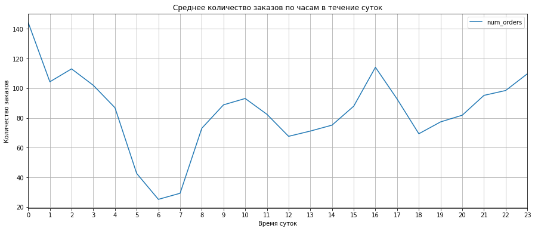

```python
data.groupby(data.index.hour).mean().plot(
    title='Среднее количество заказов по часам в течение суток',
    xlabel='Время суток',
    ylabel='Количество заказов',
    xlim=(0, 23),
    grid=True
)

plt.gca().xaxis.set_major_locator(ticker.MultipleLocator(1))
plt.show()
```

Наибольшее количество заказов поступает в полночь, наименьшее - в 6 утра. В основном самый высокий спрос на такси держится с 21 вечера и вплоть до 4 утра. Далее идет резкий спад - меньше всего заказов приходится на время с 5 до 7 утра. С 8 утра спрос поднимается до среднего уровня и с некоторыми колебаниями остается примерно на том же уровне до 20 вечера с переменным повышением спроса в 10 и 16 часов и понижением в 12 и 18 часов.

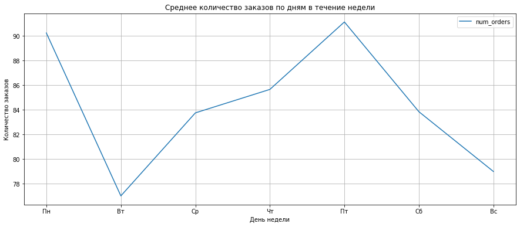

```python
data.groupby(data.index.weekday).mean().plot(
    title='Среднее количество заказов по дням в течение недели',
    xlabel='День недели',
    ylabel='Количество заказов',
    grid=True
)
plt.xticks(ticks=range(7),
           labels=['Пн', 'Вт', 'Ср', 'Чт', 'Пт', 'Сб', 'Вс'])
plt.show()
```

Наибольшее количество заказов такси приходится на пятницу и понедельник, а наименьшее на вторник и воскресенье. Виден стабильный рост спроса со вторника на пятницу, и также его стабильное снижение с пятницы и до воскресенья.

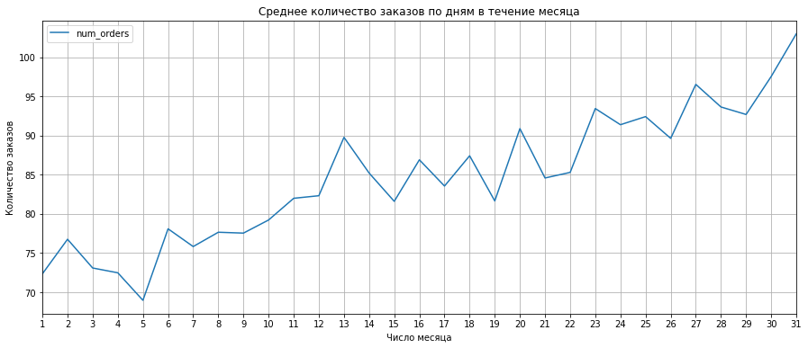

```python
 # Распределение заказов по дням в течение месяца
data.groupby(data.index.day).mean().plot(
    title='Среднее количество заказов по дням в течение месяца',
    xlabel='Число месяца',
    ylabel='Количество заказов',
    xlim=(1, 31),
    grid=True
)

plt.gca().xaxis.set_major_locator(ticker.MultipleLocator(1))
plt.show()
```

От начала к концу месяца виден рост спраса на такси, что в целом сходится с общим трендом. Наименьшее количество заказов выпадало по 5 числам месяцев, а наибольшее - по 31 числам.

### Декомпозиция на тренд, сезонную компоненту и остаток

Изучим тренд, сезонную компоненту и остаток заказов такси.

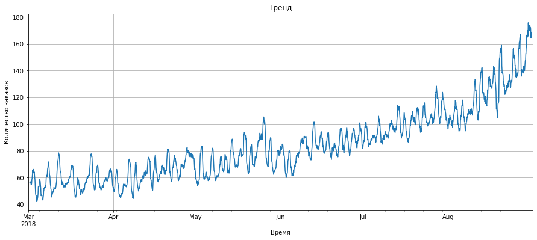

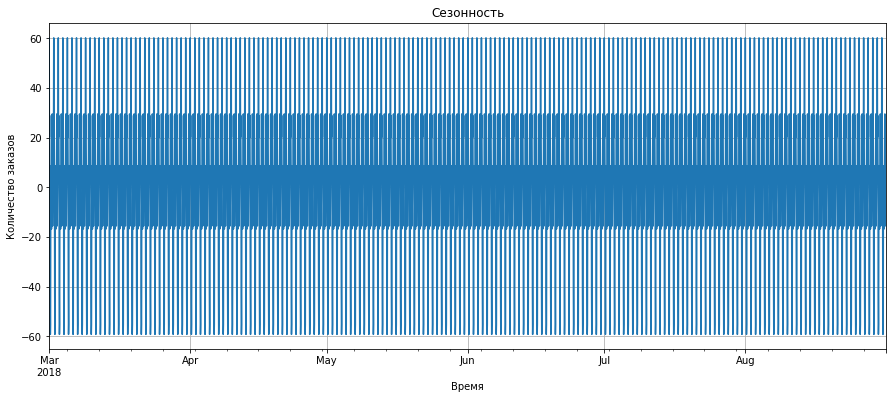

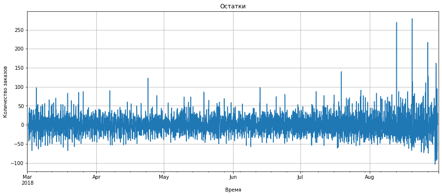

```python
decomposed_hours = seasonal_decompose(data)

components = {
    'Тренд': decomposed_hours.trend,
    'Сезонность': decomposed_hours.seasonal,
    'Остатки': decomposed_hours.resid
}

for title, component in components.items():
    component.plot(
        title=title,
        xlabel='Время',
        ylabel='Количество заказов',
        grid=True)

    plt.show()
```

Здесь мы также видим постепенно растущий тренд. В августе колебания остатков отличаются от других месяцев, заметны большие выбросы.

Сезонность в текущем интервале времени рассмотреть невозможно, необходимо уменьшить промежуток времени.

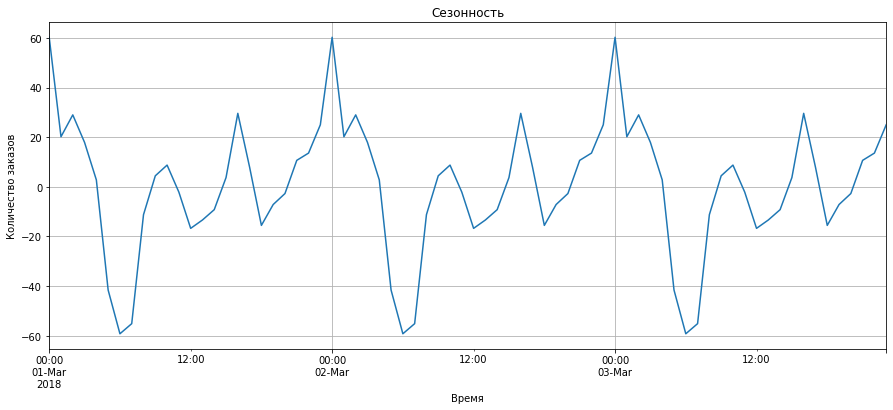

```python
decomposed_hours.seasonal['2018-03-01':'2018-03-03'].plot(
    title='Сезонность',
    xlabel='Время',
    ylabel='Количество заказов',
    grid=True);
```

Здесь мы видим полное совпадение графика со средним количеством заказов по часам в течение суток.

Также декомпозируем данные, ресемплированные по одному дню.

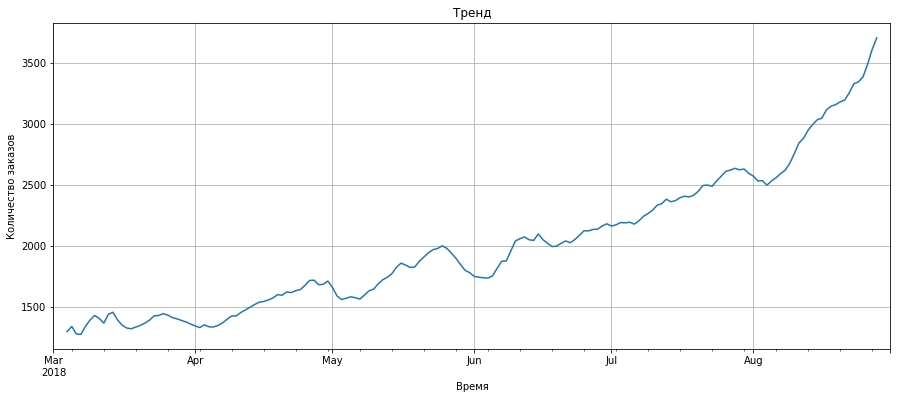

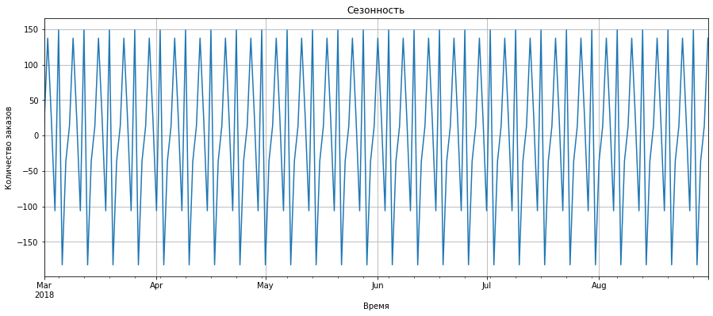

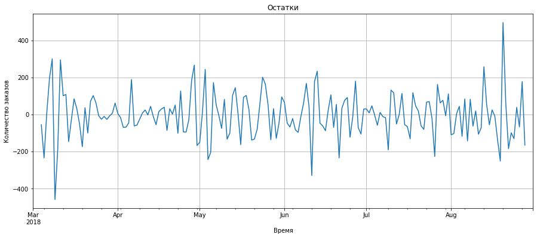

```python
decomposed_days = seasonal_decompose(data.resample('1D').sum())

components = {
    'Тренд': decomposed_days.trend,
    'Сезонность': decomposed_days.seasonal,
    'Остатки': decomposed_days.resid
}

for title, component in components.items():
    component.plot(
        title=title,
        xlabel='Время',
        ylabel='Количество заказов',
        grid=True)

    plt.show()
```

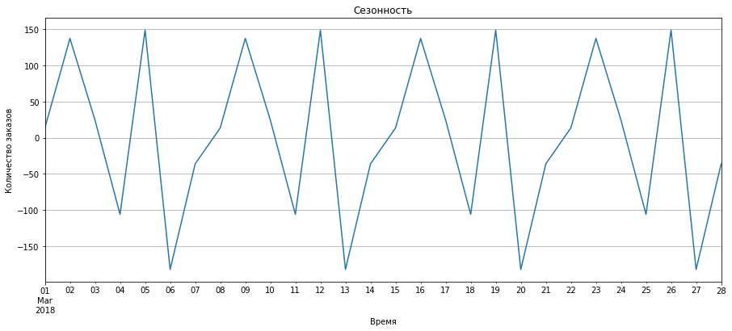

```python
decomposed_days.seasonal['2018-03-01':'2018-03-28'].plot(
    title='Сезонность',
    xlabel='Время',
    ylabel='Количество заказов',
    grid=True);
```

Здесь мы уже можем заметить недельную сезонность - график совпадает со средним количеством заказов по дням недели.

### Анализ скользящей средней и скользящего стандартного отклонения

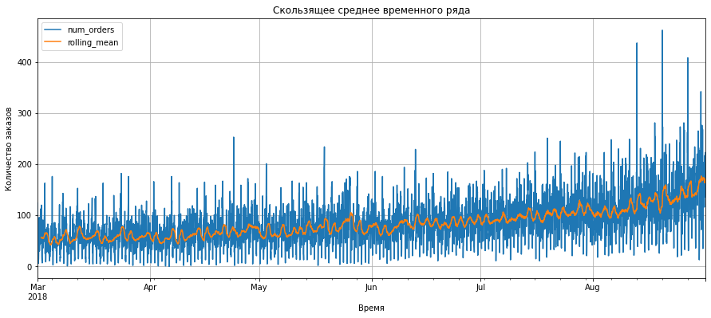

```python
data['rolling_mean'] = data.rolling(24, closed='left').mean()
data.plot(
    title='Скользящее среднее временного ряда',
    xlabel='Время',
    ylabel='Количество заказов',
    grid=True
);
data = data.drop('rolling_mean', axis=1)
```

У скользящего среднего мы также видим тренд роста.

Среднее значение со временем меняется - значит, временной ряд является нестационарным по тренду. Рассмотрим разности временного ряда.

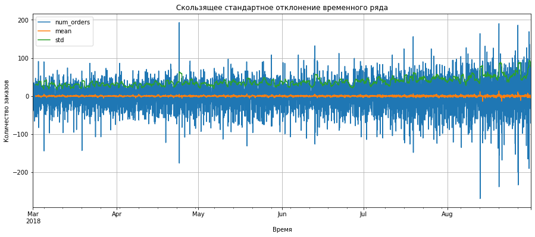

```python
data_shifted = data - data.shift()

data_shifted['mean'] = data_shifted['num_orders'].rolling(24).mean()
data_shifted['std'] = data_shifted['num_orders'].rolling(24).std()

data_shifted.plot(
    title='Скользящее стандартное отклонение временного ряда',
    xlabel='Время',
    ylabel='Количество заказов',
    grid=True
);
```

Ряд стал более стационарным, но в конце стандартное отклонение немного повышается в конце августа, а также увеличивается доля остатков.

### Вывод

Внутрисуточная сезонность особенно выражена, с минимумом заказов в ранние утренние часы (5-7 утра) и максимумом в позднее время суток (с 9 вечера до 4 утра) с пиком в 12 ночи. Днем спрос идет волнообразно - поднимается в 10 утра и 4 дня, падает в 12 дня и 6 вечера.

Также имеется сезонность по дням недели, в среднем понедельник и пятница отмечаются более высокой активностью, а во вторник и выходные дни активность снижается.

В целом, начиная с апреля наблюдается положительный тренд роста количества заказов с его ускорением в августе, что свидетельствует о стабильном росте заказов и развитии компании. Этот тренд, однако, не является идеально гладким и сопровождается колебаниями. В августе наблюдались существенные выбросы в остатках, которые могут повлиять на точность прогнозов.

Временной ряд не является стационарным. Однако, после расчета разности временного ряда график показал стационарность.

Вернуться к содержанию

## Подготовка к обучению

### Добавление признаков

Для повышения точности предсказания моделей при помощи функции `make_features` добавим в датафрейм новые признаки:

- часы суток,
- число дня,
- день недели,
- скользящая средняя за сутки,
- временные сдвиги с интервалом в час от 1 до 24 часов, а также с интервалом в сутки до 7 дней (48 - 168 часов).

Создаем функцию.

```python
# Функция для добавления новых признаков во временной ряд.
def make_features(data_new):
    # Добавляем календарные признаки
    data_new = data.copy()
    data_new['hour'] = data_new.index.hour
    data_new['day'] = data_new.index.day
    data_new['dayofweek'] = data_new.index.dayofweek

    interval = 24
    interval_count = 7

    # Добавляем временные сдвиги с интервалом в час от 1 до 24 часов.
    for lag in range(1, interval + 1):
        data_new['lag_{}'.format(lag)] = data_new['num_orders'].shift(lag)

    # Добавляем временные сдвиги с интервалом в сутки до 7 дней.
    for i in range(1, interval_count):
        lag = interval + interval * i
        data_new['lag_{}'.format(lag)] = data_new['num_orders'].shift(lag)

    # Добавляем скользящую среднюю
    data_new['rolling_mean'] = data_new['num_orders'].shift().rolling(
        window=interval
    ).mean()

    return data_new
```

Применяем функцию и проверяем результат.

```python
data_new = make_features(data)

print('Размер датафрейма: ', data_new.shape)
data_new.head()
```

```
Размер датафрейма:  (4416, 35)
```

| datetime | num_orders | hour | day | dayofweek | lag_1 | lag_2 | lag_3 | lag_4 | lag_5 | lag_6 | ... | lag_22 | lag_23 | lag_24 | lag_48 | lag_72 | lag_96 | lag_120 | lag_144 | lag_168 | rolling_mean |
| --- | --- | --- | --- | --- | --- | --- | --- | --- | --- | --- | --- | --- | --- | --- | --- | --- | --- | --- | --- | --- | --- |
| 2018-03-01 00:00:00 | 124 | 0 | 1 | 3 | NaN | NaN | NaN | NaN | NaN | NaN | ... | NaN | NaN | NaN | NaN | NaN | NaN | NaN | NaN | NaN | NaN |
| 2018-03-01 01:00:00 | 85 | 1 | 1 | 3 | 124.0 | NaN | NaN | NaN | NaN | NaN | ... | NaN | NaN | NaN | NaN | NaN | NaN | NaN | NaN | NaN | NaN |
| 2018-03-01 02:00:00 | 71 | 2 | 1 | 3 | 85.0 | 124.0 | NaN | NaN | NaN | NaN | ... | NaN | NaN | NaN | NaN | NaN | NaN | NaN | NaN | NaN | NaN |
| 2018-03-01 03:00:00 | 66 | 3 | 1 | 3 | 71.0 | 85.0 | 124.0 | NaN | NaN | NaN | ... | NaN | NaN | NaN | NaN | NaN | NaN | NaN | NaN | NaN | NaN |
| 2018-03-01 04:00:00 | 43 | 4 | 1 | 3 | 66.0 | 71.0 | 85.0 | 124.0 | NaN | NaN | ... | NaN | NaN | NaN | NaN | NaN | NaN | NaN | NaN | NaN | NaN |

5 rows × 35 columns

Мы добавили 34 новых признака.

В данных появились пропуски, т.к. заполнить сдвиги у первых записей нечем. Проверим их количество.

```python
print(
    f'Количество записей, имеющих хотя бы один пропуск: '\
    f'{data_new[data_new.columns].isna().any(axis=1).sum()} '\
    f'({round((data_new[data_new.columns].isna().any(axis=1).sum() / data_new.shape[0] * 100), 1)}%)'
)
```

```
Количество записей, имеющих хотя бы один пропуск: 168 (3.8%)
```

Количество данных с пропусками небольшое, мы можем удалить 3.8% данных.

```python
data_new = data_new.dropna()
```

Проверяем результат.

```python
print(
    f'Количество записей, имеющих хотя бы один пропуск: '\
    f'{data_new[data_new.columns].isna().any(axis=1).sum()} '\
    f'({round((data_new[data_new.columns].isna().any(axis=1).sum() / data_new.shape[0] * 100), 1)}%)'
)
```

```
Количество записей, имеющих хотя бы один пропуск: 0 (0.0%)
```

Изучим матрицу корреляции признаков.

```python
display(HTML(f'<br><h3>Матрица корреляции признаков</h3>'))
display(data_new.phik_matrix(interval_cols=data_new.columns)\
        .style.background_gradient('cividis'))
```

Матрица корреляции признаков

|  | num_orders | hour | day | dayofweek | lag_1 | lag_2 | lag_3 | lag_4 | lag_5 | lag_6 | lag_7 | lag_8 | lag_9 | lag_10 | lag_11 | lag_12 | lag_13 | lag_14 | lag_15 | lag_16 | lag_17 | lag_18 | lag_19 | lag_20 | lag_21 | lag_22 | lag_23 | lag_24 | lag_48 | … |
| --- | --- | --- | --- | --- | --- | --- | --- | --- | --- | --- | --- | --- | --- | --- | --- | --- | --- | --- | --- | --- | --- | --- | --- | --- | --- | --- | --- | --- | --- | --- |
| num_orders | 1.000000 | 0.566190 | 0.150930 | 0.074686 | 0.651113 | 0.669751 | 0.402665 | 0.308179 | 0.313596 | 0.363714 | 0.420262 | 0.363789 | 0.316978 | 0.294074 | 0.370093 | 0.331333 | 0.342844 | 0.308588 | 0.330246 | 0.337179 | 0.387020 | 0.342889 | 0.241016 | 0.281824 | 0.314104 | 0.409438 | 0.590283 | 0.695922 | 0.584892 | … |
| hour | 0.566190 | 1.000000 | 0.000000 | 0.000000 | 0.575654 | 0.619662 | 0.578485 | 0.614267 | 0.584755 | 0.630610 | 0.564096 | 0.567373 | 0.621963 | 0.567741 | 0.619052 | 0.590667 | 0.632512 | 0.568311 | 0.569520 | 0.620897 | 0.550808 | 0.566591 | 0.628687 | 0.578824 | 0.612588 | 0.583917 | 0.620063 | 0.567441 | 0.440676 | … |
| day | 0.150930 | 0.000000 | 1.000000 | 0.148258 | 0.148058 | 0.146994 | 0.148785 | 0.150689 | 0.150398 | 0.147812 | 0.147030 | 0.151478 | 0.153897 | 0.155781 | 0.155762 | 0.153987 | 0.153669 | 0.152919 | 0.153766 | 0.152694 | 0.152438 | 0.151902 | 0.152637 | 0.143936 | 0.138513 | 0.138090 | 0.135135 | 0.140023 | 0.099917 | … |
| dayofweek | 0.074686 | 0.000000 | 0.148258 | 1.000000 | 0.082213 | 0.085464 | 0.087694 | 0.098197 | 0.096090 | 0.095038 | 0.099226 | 0.101269 | 0.091969 | 0.099646 | 0.101430 | 0.108836 | 0.103495 | 0.103240 | 0.098136 | 0.097578 | 0.093930 | 0.094287 | 0.092154 | 0.084920 | 0.075926 | 0.072800 | 0.056297 | 0.068092 | 0.065945 | … |
| lag_1 | 0.651113 | 0.575654 | 0.148058 | 0.082213 | 1.000000 | 0.650461 | 0.669811 | 0.402258 | 0.308368 | 0.312381 | 0.362342 | 0.419079 | 0.364145 | 0.317320 | 0.292864 | 0.370195 | 0.330521 | 0.341829 | 0.307292 | 0.328828 | 0.338109 | 0.387213 | 0.343209 | 0.238053 | 0.281703 | 0.311665 | 0.407606 | 0.590830 | 0.448287 | … |
| lag_2 | 0.669751 | 0.619662 | 0.146994 | 0.085464 | 0.650461 | 1.000000 | 0.650569 | 0.669842 | 0.402297 | 0.306215 | 0.311235 | 0.360918 | 0.418925 | 0.364237 | 0.316538 | 0.293122 | 0.369364 | 0.327240 | 0.341440 | 0.305841 | 0.329460 | 0.339090 | 0.387907 | 0.342317 | 0.237984 | 0.280094 | 0.309605 | 0.407105 | 0.362063 | … |
| lag_3 | 0.402665 | 0.578485 | 0.148785 | 0.087694 | 0.669811 | 0.650569 | 1.000000 | 0.650330 | 0.669820 | 0.402195 | 0.305654 | 0.310548 | 0.360753 | 0.418460 | 0.364006 | 0.316455 | 0.292310 | 0.368571 | 0.326535 | 0.340489 | 0.306189 | 0.329742 | 0.339323 | 0.386691 | 0.342292 | 0.236391 | 0.279475 | 0.308199 | 0.224975 | … |
| lag_4 | 0.308179 | 0.614267 | 0.150689 | 0.098197 | 0.402258 | 0.669842 | 0.650330 | 1.000000 | 0.650368 | 0.669797 | 0.402120 | 0.305396 | 0.310409 | 0.360746 | 0.418103 | 0.364066 | 0.316565 | 0.291515 | 0.367923 | 0.326153 | 0.341286 | 0.306987 | 0.330187 | 0.337566 | 0.386898 | 0.341060 | 0.235075 | 0.277278 | 0.213298 | … |
| lag_5 | 0.313596 | 0.584755 | 0.150398 | 0.096090 | 0.308368 | 0.402297 | 0.669820 | 0.650368 | 1.000000 | 0.650622 | 0.669939 | 0.402385 | 0.305317 | 0.310391 | 0.360864 | 0.418178 | 0.364145 | 0.316816 | 0.291363 | 0.367962 | 0.326504 | 0.341812 | 0.307216 | 0.332278 | 0.337472 | 0.387161 | 0.341067 | 0.235010 | 0.210724 | … |
| lag_6 | 0.363714 | 0.630610 | 0.147812 | 0.095038 | 0.312381 | 0.306215 | 0.402195 | 0.669797 | 0.650622 | 1.000000 | 0.649895 | 0.669190 | 0.402443 | 0.305379 | 0.309312 | 0.360561 | 0.417658 | 0.362635 | 0.314804 | 0.290412 | 0.368538 | 0.327328 | 0.342119 | 0.305332 | 0.332393 | 0.335924 | 0.385520 | 0.341500 | 0.202756 | … |
| lag_7 | 0.420262 | 0.564096 | 0.147030 | 0.099226 | 0.362342 | 0.311235 | 0.305654 | 0.402120 | 0.669939 | 0.649895 | 1.000000 | 0.649161 | 0.669358 | 0.402624 | 0.305077 | 0.309422 | 0.359710 | 0.417073 | 0.361621 | 0.314234 | 0.291050 | 0.369252 | 0.328153 | 0.342980 | 0.305423 | 0.331516 | 0.334656 | 0.384360 | 0.308325 | … |
| lag_8 | 0.363789 | 0.567373 | 0.151478 | 0.101269 | 0.419079 | 0.360918 | 0.310548 | 0.305396 | 0.402385 | 0.669190 | 0.649161 | 1.000000 | 0.649275 | 0.669615 | 0.402270 | 0.305304 | 0.308362 | 0.358856 | 0.416470 | 0.360616 | 0.314901 | 0.291576 | 0.369807 | 0.328983 | 0.343295 | 0.304208 | 0.330670 | 0.330880 | 0.219236 | … |
| lag_9 | 0.316978 | 0.621963 | 0.153897 | 0.091969 | 0.364145 | 0.418925 | 0.360753 | 0.310409 | 0.305317 | 0.402443 | 0.669358 | 0.649275 | 1.000000 | 0.649134 | 0.669639 | 0.402322 | 0.305355 | 0.308526 | 0.359164 | 0.416651 | 0.361081 | 0.315038 | 0.291831 | 0.370089 | 0.328862 | 0.343466 | 0.304473 | 0.333000 | 0.204464 | … |
| lag_10 | 0.294074 | 0.567741 | 0.155781 | 0.099646 | 0.317320 | 0.364237 | 0.418460 | 0.360746 | 0.310391 | 0.305379 | 0.402624 | 0.669615 | 0.649134 | 1.000000 | 0.649067 | 0.669704 | 0.402352 | 0.305450 | 0.308516 | 0.359340 | 0.417001 | 0.361341 | 0.314988 | 0.292950 | 0.370084 | 0.329440 | 0.343364 | 0.304680 | 0.182449 | … |
| lag_11 | 0.370093 | 0.619052 | 0.155762 | 0.101430 | 0.292864 | 0.316538 | 0.364006 | 0.418103 | 0.360864 | 0.309312 | 0.305077 | 0.402270 | 0.669639 | 0.649067 | 1.000000 | 0.648991 | 0.669507 | 0.402410 | 0.305128 | 0.308214 | 0.360021 | 0.417729 | 0.361834 | 0.312691 | 0.293022 | 0.369493 | 0.328794 | 0.342202 | 0.216733 | … |
| lag_12 | 0.331333 | 0.590667 | 0.153987 | 0.108836 | 0.370195 | 0.293122 | 0.316455 | 0.364066 | 0.418178 | 0.360561 | 0.309422 | 0.305304 | 0.402322 | 0.669704 | 0.648991 | 1.000000 | 0.648926 | 0.669731 | 0.402618 | 0.305118 | 0.308616 | 0.360421 | 0.417741 | 0.361717 | 0.312845 | 0.292752 | 0.368954 | 0.328534 | 0.187166 | … |
| lag_13 | 0.342844 | 0.632512 | 0.153669 | 0.103495 | 0.330521 | 0.369364 | 0.292310 | 0.316565 | 0.364145 | 0.417658 | 0.359710 | 0.308362 | 0.305355 | 0.402352 | 0.669507 | 0.648926 | 1.000000 | 0.648671 | 0.669760 | 0.402269 | 0.305896 | 0.309477 | 0.360741 | 0.418000 | 0.361602 | 0.312293 | 0.291911 | 0.368154 | 0.201236 | … |
| lag_14 | 0.308588 | 0.568311 | 0.152919 | 0.103240 | 0.341829 | 0.327240 | 0.368571 | 0.291515 | 0.316816 | 0.362635 | 0.417073 | 0.358856 | 0.308526 | 0.305450 | 0.402410 | 0.669731 | 0.648671 | 1.000000 | 0.647951 | 0.669914 | 0.403081 | 0.307153 | 0.310373 | 0.360062 | 0.417726 | 0.360765 | 0.310354 | 0.286710 | 0.188885 | … |
| lag_15 | 0.330246 | 0.569520 | 0.153766 | 0.098136 | 0.307292 | 0.341440 | 0.326535 | 0.367923 | 0.291363 | 0.314804 | 0.361621 | 0.416470 | 0.359164 | 0.308516 | 0.305128 | 0.402618 | 0.669760 | 0.647951 | 1.000000 | 0.647904 | 0.670307 | 0.403961 | 0.308195 | 0.307816 | 0.360068 | 0.417525 | 0.360087 | 0.308792 | 0.200609 | … |
| lag_16 | 0.337179 | 0.620897 | 0.152694 | 0.097578 | 0.328828 | 0.305841 | 0.340489 | 0.326153 | 0.367962 | 0.290412 | 0.314234 | 0.360616 | 0.416651 | 0.359340 | 0.308214 | 0.305118 | 0.402269 | 0.669914 | 0.647904 | 1.000000 | 0.648429 | 0.670605 | 0.404320 | 0.309438 | 0.307564 | 0.359583 | 0.417120 | 0.360497 | 0.242130 | … |
| lag_17 | 0.387020 | 0.550808 | 0.152438 | 0.093930 | 0.338109 | 0.329460 | 0.306189 | 0.341286 | 0.326504 | 0.368538 | 0.291050 | 0.314901 | 0.361081 | 0.417001 | 0.360021 | 0.308616 | 0.305896 | 0.403081 | 0.670307 | 0.648429 | 1.000000 | 0.648429 | 0.670722 | 0.407149 | 0.309649 | 0.307604 | 0.359298 | 0.416497 | 0.264590 | … |
| lag_18 | 0.342889 | 0.566591 | 0.151902 | 0.094287 | 0.387213 | 0.339090 | 0.329742 | 0.306987 | 0.341812 | 0.327328 | 0.369252 | 0.291576 | 0.315038 | 0.361341 | 0.417729 | 0.360421 | 0.309477 | 0.307153 | 0.403961 | 0.670605 | 0.648429 | 1.000000 | 0.648700 | 0.671819 | 0.407293 | 0.309744 | 0.307332 | 0.358510 | 0.204470 | … |
| lag_19 | 0.241016 | 0.628687 | 0.152637 | 0.092154 | 0.343209 | 0.387907 | 0.339323 | 0.330187 | 0.307216 | 0.342119 | 0.328153 | 0.369807 | 0.291831 | 0.314988 | 0.361834 | 0.417741 | 0.360741 | 0.310373 | 0.308195 | 0.404320 | 0.670722 | 0.648700 | 1.000000 | 0.650890 | 0.671829 | 0.407899 | 0.310158 | 0.308385 | 0.185629 | … |
| lag_20 | 0.281824 | 0.578824 | 0.143936 | 0.084920 | 0.238053 | 0.342317 | 0.386691 | 0.337566 | 0.332278 | 0.305332 | 0.342980 | 0.328983 | 0.370089 | 0.292950 | 0.312691 | 0.361717 | 0.418000 | 0.360062 | 0.307816 | 0.309438 | 0.407149 | 0.671819 | 0.650890 | 1.000000 | 0.651717 | 0.671244 | 0.406801 | 0.310072 | 0.294426 | … |
| lag_21 | 0.314104 | 0.612588 | 0.138513 | 0.075926 | 0.281703 | 0.237984 | 0.342292 | 0.386898 | 0.337472 | 0.332393 | 0.305423 | 0.343295 | 0.328862 | 0.370084 | 0.293022 | 0.312845 | 0.361602 | 0.417726 | 0.360068 | 0.307564 | 0.309649 | 0.407293 | 0.671829 | 0.651717 | 1.000000 | 0.651929 | 0.671336 | 0.409591 | 0.220092 | … |
| lag_22 | 0.409438 | 0.583917 | 0.138090 | 0.072800 | 0.311665 | 0.280094 | 0.236391 | 0.341060 | 0.387161 | 0.335924 | 0.331516 | 0.304208 | 0.343466 | 0.329440 | 0.369493 | 0.292752 | 0.312293 | 0.360765 | 0.417525 | 0.359583 | 0.307604 | 0.309744 | 0.407899 | 0.671244 | 0.651929 | 1.000000 | 0.651140 | 0.670111 | 0.491399 | … |
| lag_23 | 0.590283 | 0.620063 | 0.135135 | 0.056297 | 0.407606 | 0.309605 | 0.279475 | 0.235075 | 0.341067 | 0.385520 | 0.334656 | 0.330670 | 0.304473 | 0.343364 | 0.328794 | 0.368954 | 0.291911 | 0.310354 | 0.360087 | 0.417120 | 0.359298 | 0.307332 | 0.310158 | 0.406801 | 0.671336 | 0.651140 | 1.000000 | 0.652060 | 0.438421 | … |
| lag_24 | 0.695922 | 0.567441 | 0.140023 | 0.068092 | 0.590830 | 0.407105 | 0.308199 | 0.277278 | 0.235010 | 0.341500 | 0.384360 | 0.330880 | 0.333000 | 0.304680 | 0.342202 | 0.328534 | 0.368154 | 0.286710 | 0.308792 | 0.360497 | 0.416497 | 0.358510 | 0.308385 | 0.310072 | 0.409591 | 0.670111 | 0.652060 | 1.000000 | 0.553885 | … |
| lag_48 | 0.584892 | 0.440676 | 0.099917 | 0.065945 | 0.448287 | 0.362063 | 0.224975 | 0.213298 | 0.210724 | 0.202756 | 0.308325 | 0.219236 | 0.204464 | 0.182449 | 0.216733 | 0.187166 | 0.201236 | 0.188885 | 0.200609 | 0.242130 | 0.264590 | 0.204470 | 0.185629 | 0.294426 | 0.220092 | 0.491399 | 0.438421 | 0.553885 | 1.000000 | … |
| lag_72 | 0.582689 | 0.441261 | 0.102499 | 0.071750 | 0.442183 | 0.310119 | 0.254151 | 0.168757 | 0.196768 | 0.226239 | 0.267442 | 0.243518 | 0.199729 | 0.220335 | 0.216863 | 0.229261 | 0.218313 | 0.220181 | 0.192189 | 0.234543 | 0.276643 | 0.250708 | 0.190447 | 0.280213 | 0.238964 | 0.454418 | 0.467673 | 0.581485 | 0.694006 | … |
| lag_96 | 0.589260 | 0.442835 | 0.104972 | 0.085305 | 0.457048 | 0.345415 | 0.295347 | 0.197150 | 0.214109 | 0.261826 | 0.303755 | 0.223783 | 0.648670 | 0.257885 | 0.449891 | 0.211077 | 0.213038 | 0.207149 | 0.212744 | 0.220416 | 0.267857 | 0.211786 | 0.178844 | 0.193166 | 0.205619 | 0.371591 | 0.433618 | 0.583173 | 0.724215 | … |
| lag_120 | 0.591880 | 0.450758 | 0.105658 | 0.081499 | 0.486977 | 0.432398 | 0.244223 | 0.225984 | 0.202668 | 0.226311 | 0.541534 | 0.247636 | 0.188560 | 0.289665 | 0.215253 | 0.218262 | 0.216323 | 0.242754 | 0.203598 | 0.229188 | 0.253003 | 0.214704 | 0.188175 | 0.165056 | 0.216407 | 0.318866 | 0.439483 | 0.585781 | 0.573080 | … |
| lag_144 | 0.547583 | 0.451183 | 0.106237 | 0.084806 | 0.445944 | 0.418375 | 0.217513 | 0.197585 | 0.250439 | 0.190307 | 0.309698 | 0.284446 | 0.173268 | 0.195939 | 0.215181 | 0.184091 | 0.190577 | 0.186864 | 0.185430 | 0.231986 | 0.260189 | 0.223933 | 0.194339 | 0.204037 | 0.233800 | 0.385089 | 0.457049 | 0.590731 | 0.579407 | … |
| lag_168 | 0.771505 | 0.450929 | 0.095448 | 0.081078 | 0.467542 | 0.421050 | 0.253297 | 0.193274 | 0.183975 | 0.201453 | 0.314675 | 0.236375 | 0.195905 | 0.185352 | 0.217388 | 0.205100 | 0.223072 | 0.211472 | 0.172428 | 0.220582 | 0.274565 | 0.193234 | 0.164739 | 0.170578 | 0.213007 | 0.292327 | 0.452599 | 0.545060 | 0.579296 | … |
| rolling_mean | 0.573528 | 0.000000 | 0.503483 | 0.308163 | 0.601223 | 0.606189 | 0.608114 | 0.613491 | 0.614220 | 0.611619 | 0.615367 | 0.614151 | 0.620051 | 0.621898 | 0.620116 | 0.621821 | 0.620060 | 0.618822 | 0.618064 | 0.618352 | 0.616494 | 0.613968 | 0.610969 | 0.605978 | 0.602385 | 0.601316 | 0.597558 | 0.590443 | 0.398253 | … |

Все новые признаки имеют корреляцию с целевым в той или иной степени, поэтому они все могут нам пригодиться. Наибольшую корреляцию показывают сдвиги в 168 часов (7 дней), 24 часа, 1 и 2 часа.

### Подготовка данных

В обучении мы будем использовать следующие модели:

- `LinearRegression`,
- `RandomForestRegressor`,
- `DecisionTreeRegressor`,
- `CatBoostRegressor`,
- `LGBMRegressor`.

Подготовим данные в соответствии с требованиями этих моделей.

Делим признаки на входные и целевой.

```python
X = data_new.drop('num_orders', axis=1)
y = data_new['num_orders']
```

Разбиваем признаки на тренировочные и тестовые выборки.

```python
X_train, X_temp, y_train, y_temp = train_test_split(
    X,
    y,
    shuffle=False,
    test_size=0.2
)

X_val, X_test, y_val, y_test = train_test_split(
    X_temp,
    y_temp,
    shuffle=False,
    test_size=0.5
)
```

Проверим корректность разделения получившихся выборок.

```python
for sample_name in ['X_train', 'X_val', 'X_test']:
    sample = eval(sample_name)
    print(f'\nВременной интервал у выборки {sample_name}: \n\n'
          f'{sample.index.min()} --- {sample.index.max()}\n\n')
```

```
Временной интервал у выборки X_train:

2018-03-08 00:00:00 --- 2018-07-27 13:00:00



Временной интервал у выборки X_val:

2018-07-27 14:00:00 --- 2018-08-14 06:00:00



Временной интервал у выборки X_test:

2018-08-14 07:00:00 --- 2018-08-31 23:00:00
```

```python
for sample_name in ['X_train', 'X_val', 'X_test']:
    sample = eval(sample_name)
    print(f'Доля выборки {sample_name}: '
          f'{sample.shape[0]/data_new.shape[0]:.0%}, '
          f'количество столбцов: {sample.shape[1]}')

print('\n')

for sample_name in ['y_train', 'y_val', 'y_test']:
    sample = eval(sample_name)
    print(f'Доля выборки {sample_name}: '
          f'{sample.shape[0]/data_new.shape[0]:.0%}')
```

```
Доля выборки X_train: 80%, количество столбцов: 34
Доля выборки X_val: 10%, количество столбцов: 34
Доля выборки X_test: 10%, количество столбцов: 34


Доля выборки y_train: 80%
Доля выборки y_val: 10%
Доля выборки y_test: 10%
```

Для линейной регрессии отмасштабируем данные с помощью `StandardScaler`.

```python
preprocessor = ColumnTransformer(
    transformers=[
        ('num', StandardScaler(), X.columns),
    ], remainder='passthrough')
```

### Подготовка моделей

Для каждой модели подберем разные гиперпараметры.

**Модель LinearRegression**

```python
lr_model = Pipeline(
    steps=[('preprocessor', preprocessor),
           ('regressor', LinearRegression())])
```

**Модель RandomForestRegressor**

```python
rf_model = RandomForestRegressor(
    n_estimators=50,
    max_depth=10,
    min_samples_split=10,
    min_samples_leaf=4,
    random_state=RANDOM_STATE)
```

**Модель DecisionTreeRegressor**

```python
dtr_model = DecisionTreeRegressor(
    max_depth=50,
    min_samples_split=20,
    min_samples_leaf=10,
    random_state=RANDOM_STATE
)
```

**Модель LGBMRegressor**

```python
lgb_model = lgb.LGBMRegressor(
    n_estimators=100,
    learning_rate=0.1,
    max_depth=10,
    random_state=RANDOM_STATE
)
```

**Модель CatBoostRegressor**

```python
cat_model = CatBoostRegressor(
    subsample=1,
    leaf_estimation_iterations=10,
    random_strength=0.5,
    depth=6,
    random_state=RANDOM_STATE,
    verbose=0
)
```

### Вывод

В результате подготовки к обучению мы:

- Добавили в датафрейм 34 новых признака и удалили 3.8% пропусков. Наибольшую корреляцию с целевым признаком показали сдвиги в 168 часов (7 дней), 24 часа, 1 и 2 часа.
- Подготовили тренировочные и тестовые выборки, а также отмасштабированные выборки отдельно для модели линейной регрессии.
- Подготовили 5 моделей с разными гиперпараметрами.

Вернуться к содержанию

## Обучение и тестирование

### Получение результатов

Создаем таблицу, в которой мы будем сохранять результаты моделей.

```python
results = pd.DataFrame(columns=['Model',
                                'Training Time',
                                'Prediction Time',
                                'RMSE'])
```

При помощи функции `model_results` обучаем модель, предсказываем результаты и выводим на экран ее метрики.

```python
# Функция для обучения модели, предсказания результатов
# и получения ее метрик качества.
def model_results(model, model_name,
                  X_train, y_train,
                  X_val, y_val,
                  results):

    # Обучение модели и фиксирование времени.
    start_time = time.time()
    model.fit(X_train, y_train)
    train_time = time.time() - start_time

    # Получение предсказаний модели и фиксирование времени.
    start_time = time.time()
    val_pred = model.predict(X_val)
    pred_time = time.time() - start_time

    # Расчет точности RMSE модели на тестовой выборке.
    rmse = mean_squared_error(y_val, val_pred, squared=False)

    # Сохранение результатов.
    results = results.append(
        {'Model': model_name,
         'Training Time': train_time,
         'Prediction Time': pred_time,
         'RMSE': rmse},
        ignore_index=True)

    return model, results
```

**Модель LinearRegression**

```python
lr_model, results = model_results(
    lr_model,
    'LinearRegression',
    X_train,
    y_train,
    X_val,
    y_val,
    results
)

display(results.tail(1))
```

|  | Model | Training Time | Prediction Time | RMSE |
| --- | --- | --- | --- | --- |
| 0 | LinearRegression | 0.012335 | 0.127306 | 29.500871 |

**Модель RandomForestRegressor**

```python
rf_model, results = model_results(
    rf_model,
    'RandomForest',
    X_train,
    y_train,
    X_val,
    y_val,
    results
)

display(results.tail(1))
```

|  | Model | Training Time | Prediction Time | RMSE |
| --- | --- | --- | --- | --- |
| 1 | RandomForest | 1.684432 | 0.008549 | 30.546239 |

**Модель DecisionTreeRegressor**

```python
dtr_model, results = model_results(
    dtr_model,
    'DecisionTree',
    X_train,
    y_train,
    X_val,
    y_val,
    results
)

display(results.tail(1))
```

|  | Model | Training Time | Prediction Time | RMSE |
| --- | --- | --- | --- | --- |
| 2 | DecisionTree | 0.054586 | 0.001662 | 33.103391 |

**Модель LGBMRegressor**

```python
lgb_model, results = model_results(
    lgb_model,
    'LightGBM',
    X_train,
    y_train,
    X_val,
    y_val,
    results
)

display(results.tail(1))
```

|  | Model | Training Time | Prediction Time | RMSE |
| --- | --- | --- | --- | --- |
| 3 | LightGBM | 9.222578 | 0.003517 | 30.392222 |

**Модель CatBoostRegressor**

```python
cat_model, results = model_results(
    cat_model,
    'CatBoost',
    X_train,
    y_train,
    X_val,
    y_val,
    results
)

display(results.tail(1))
```

|  | Model | Training Time | Prediction Time | RMSE |
| --- | --- | --- | --- | --- |
| 4 | CatBoost | 6.981928 | 0.002774 | 30.067902 |

### Анализ моделей

Сравним результаты всех моделей.

```python
display(results)
```

|  | Model | Training Time | Prediction Time | RMSE |
| --- | --- | --- | --- | --- |
| 0 | LinearRegression | 0.012335 | 0.127306 | 29.500871 |
| 1 | RandomForest | 1.684432 | 0.008549 | 30.546239 |
| 2 | DecisionTree | 0.054586 | 0.001662 | 33.103391 |
| 3 | LightGBM | 9.222578 | 0.003517 | 30.392222 |
| 4 | CatBoost | 6.981928 | 0.002774 | 30.067902 |

Построим графики сравнения предсказанных и фактических значений моделей.

```python
models = {
    'LinearRegression': lr_model,
    'RandomForestRegressor': rf_model,
    'DecisionTreeRegressor': dtr_model,
    'LGBMRegressor': lgb_model,
    'CatBoostRegressor': cat_model
}
```

```python
for model_name, model in models.items():
    test_predictions = model.predict(X_test)
    test_rmse = round(
        mean_squared_error(
            y_test,
            test_predictions,
            squared=False
        ), 2)

    print(f'RMSE модели {model_name} на тестовой выборке: {test_rmse}')
```

```
RMSE модели LinearRegression на тестовой выборке: 34.31
RMSE модели RandomForestRegressor на тестовой выборке: 45.19
RMSE модели DecisionTreeRegressor на тестовой выборке: 49.6
RMSE модели LGBMRegressor на тестовой выборке: 47.22
RMSE модели CatBoostRegressor на тестовой выборке: 45.77
```

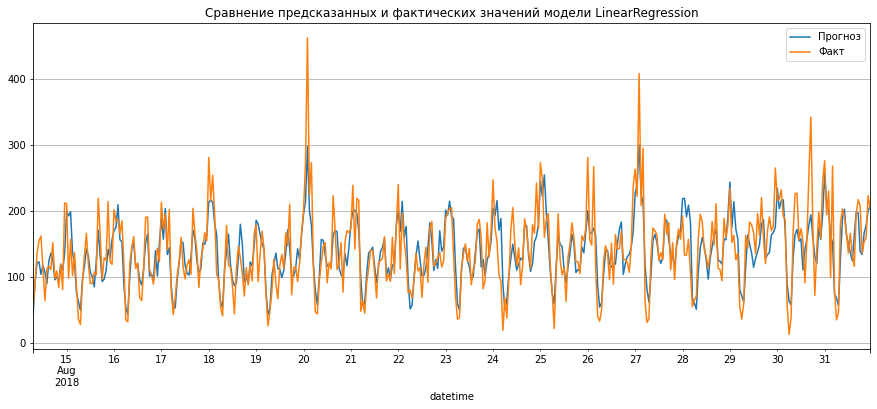

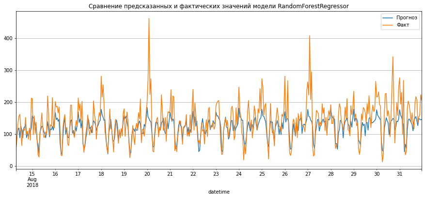

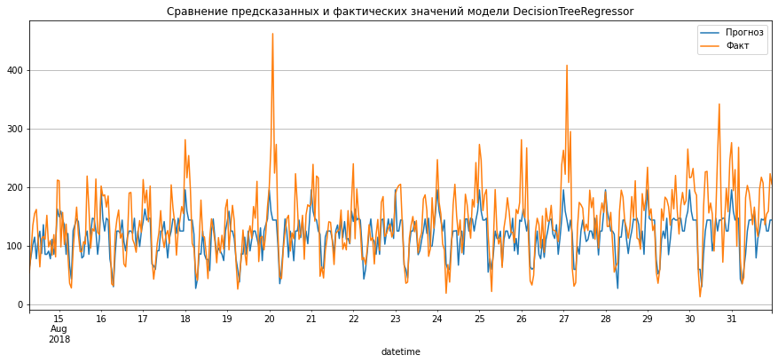

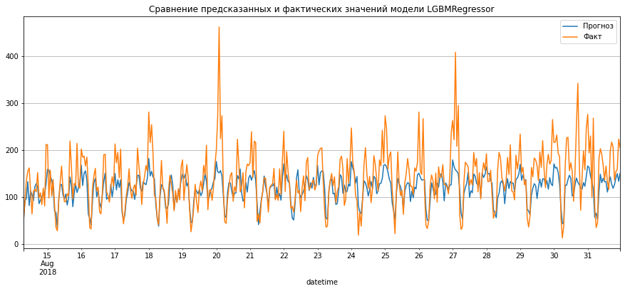

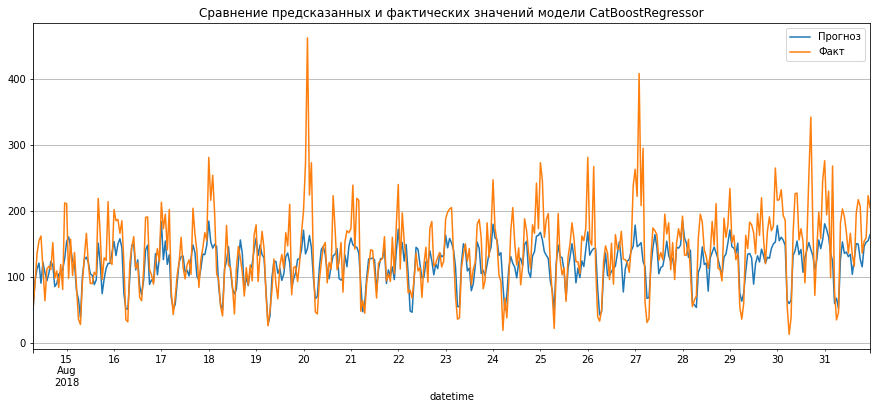

```python
for model_name, model in models.items():

    pd.DataFrame(
        {'Прогноз':model.predict(X_test),
         'Факт':y_test}
    ).plot(
    grid=True)
    plt.title(f'Сравнение предсказанных и фактических '
              f'значений модели {model_name}')
    plt.show()
```

Модель DecisionTreeRegressor имеет самый низкий показатель точности среди обученных нами моделей и не соответствует требованиям заказчика.

Все остальные модели показали тот уровень точности, который требовался заказчику - метрика RMSE меньше 48.

Наилучший показатель точности имеет модель LinearRegression, также она быстрее всего обучается.

На графиках-сравнении предсказанных и фактических значений мы можем увидеть, что для предсказания моделям сложнее всего даются предсказания в пиковые часы, где количество заказов резко возрастает. Предсказания таких пиков у модели LinearRegression ближе всего к фактическим по сравнению с другими моделями, но даже ее прогнозы далеки от факта. Это связано с большей долей остатков в августе.

Вернуться к содержанию

## Общий вывод

**Описание задачи**

В данной проектной работе мы помогли компании «Чётенькое такси» построить модель для прогноза количества заказов такси на следующий час для привлечения больше водителей в период пиковой нагрузки.

**Этапы работы**

*Загрузка и первичное изучение информации о данных:*

26496 записей за период с 1 марта по 31 августа 2018 года по количеству заказов такси с интервалом в 10 минут. После ресемплирования у нас осталось 4416 записей с интервалом в 1 час.

*Анализ данных:*

Выявили внутрисуточную сезонность - спрос на такси повышается ночью с пиком в 12 ночи, и в 5-7 утра он падает до минимальных значений. В течение дня спрос держится на среднем уровне с некоторыми колебаниями.

В среднем понедельник и пятница отмечаются более высокой активностью, а во вторник и выходные дни активность снижается.

В целом, наблюдается положительный тренд роста количества заказов, что свидетельствует о стабильном росте заказов и развитии компании.

Временной ряд не является стационарным. Однако, после расчета разности временного ряда график показал стационарность.

*Подготовка к обучению:*

Мы добавили в датафрейм 34 новых признака и удалили 3.8% пропусков. Наибольшую корреляцию с целевым признаком показали сдвиги в 168 часов (7 дней), 24 часа, 1 и 2 часа.

Для задачи мы выбрали 5 моделей: LinearRegression, RandomForestRegressor, DecisionTreeRegressor, LGBMRegressor, CatBoostRegressor.

*Обучение и тестирование моделей:*

Модель DecisionTreeRegressor показала самую худшую точность среди обученных нами моделей как на валидационной (33.1), так и на тестовой выборке (49.6).

Заказчику рекомендуется использовать LinearRegression для прогноза количества заказов такси на следующий час.

Вернуться к содержанию